# Pedogenesis_Data_Project

Phoebe Teskey

2026-04-30

*Soil Data Project* The attached spreadsheets contain 1) summary of the PDI and WM PDI values for the McAuliffe 1994 paper and the SRER soil chronosequence, and 2) compiled long-term vegetation transect from the SRER that includes data for mean annual precipitation (MAP) and surficial geologic map unit (MapUnit) that corresponds with estimated landscape age. This assignment will consist of several components.

*Component 1 - McAuliffe Paper*

1. How do the calculated PDI and WM PDI values relate to vegetation abundance, diversity, structural form across the three fan complexes detailed in the paper? Were your hypotheses from the McAuliffe reading assignment confirmed?

PDI values can be used as a proxy for determining and understanding vegetation composition. A higher PDI value indicates older, more developed soils, which tend to have higher clay content and less water penetration, selecting for shallow rooted plants such as grasses. Intermediate PDI values are moderately developed, with some clay accumulation and some deeper water infiltration possible. We see a high plant diversity here, as this soil can support both shallow rooted and some deep-rooted plants. Woody shrubs, perennial grass and mesquite are common. The lower PDI values indicate the least developed soils, with low clay content and deep, rapid water infiltration. This selects for deeply rooted plants such as mesquite and some shrubs. However, McAuliffe finds that “Vegetation patterns are not continuous along a gradient and instead show strong spatial heterogeneity tied to geomorphic surfaces”. He found that soil age does not necessarily inform PDI values. The paper exemplifies this. The Tucson Mountains sites exhibit both high and low PDI value sites, with low PDI sites having more woody species and high PDI sites having more grass and shrubs together. This loosely follows the general metric I described in the first paragraph.

The Silverbell Mountains sites follow the vegetation/PDI metric most closely, with woody species on young soils (low PDI) and mixed grass/shrubs on middle-aged surfaces.

The Tortolitas are the least consistent. Some of the sites are very old, but can support trees and shrubs, likely due to the high erosion at the site, lending younger soil characteristics.

My hypotheses are here: 1. As clay and carbonates increase, so does shrub dominance. 2. Plant diversity will peak at mid-aged soils with both grasses and shrubs. 3. Higher clay accumulations will select for shrubs because thicker, more sturdy roots are required to penetrate clays and argillic horizons.

The first hypothesis is blatantly incorrect. Clay accumulation is generally associated more with perennial grasses, not shrubs.

The second hypothesis follows the general PDI/vegetation metric seen in the Tucson Mtns and Silverbells, but the Tortolitas provide an exception to these general rules. As McAuliffe found, soil age is not always a strong predictor of PDI values.

The third hypothesis is also false and is an iteration of the first. I don’t know what I was thinking.

2. How does erosion impact PDI and WM PDI on the different surfaces and what key soil features differ between the two surfaces that causes the change in profile development?

Erosion lends a lower PDI value to sites regardless of soil age. A site with higher erosion has faster and deeper water infiltration, selecting for plants that can access deeper water, like mesquite. This makes sense in the Tortolitas, particularly because many of the surfaces there are granitic, decomposing bedrock. The particle size is going to be larger, clay content is lower, and in many ways, soil formation has been reset.

*Component 2 - SRER Chronosequence*

1. Plot both PDI and WM PDI versus estimated soil age - using both the actual values and as a semi-log plot with soil age on a log scale. Provide detail on how both change relative to soil age as well as proposed explanations for the observed patterns.

```r
library(tidyverse)
```

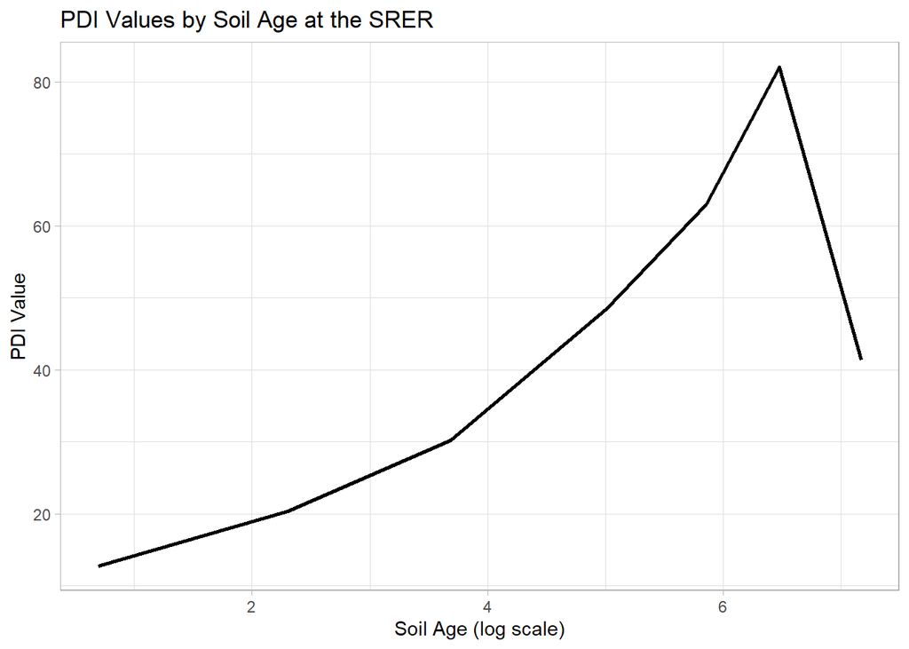

```r
SRER <- read.csv("../data/SRER2.csv")

SRER1 <- mutate(SRER, age_log = log(Age))

ggplot(SRER1, aes(x = age_log))+
  geom_line(aes(y = PDI), linewidth = 1) +
  theme_light() +
  labs(title = "PDI Values by Soil Age at the SRER", x = "Soil Age (log scale)", y = "PDI Value")
```

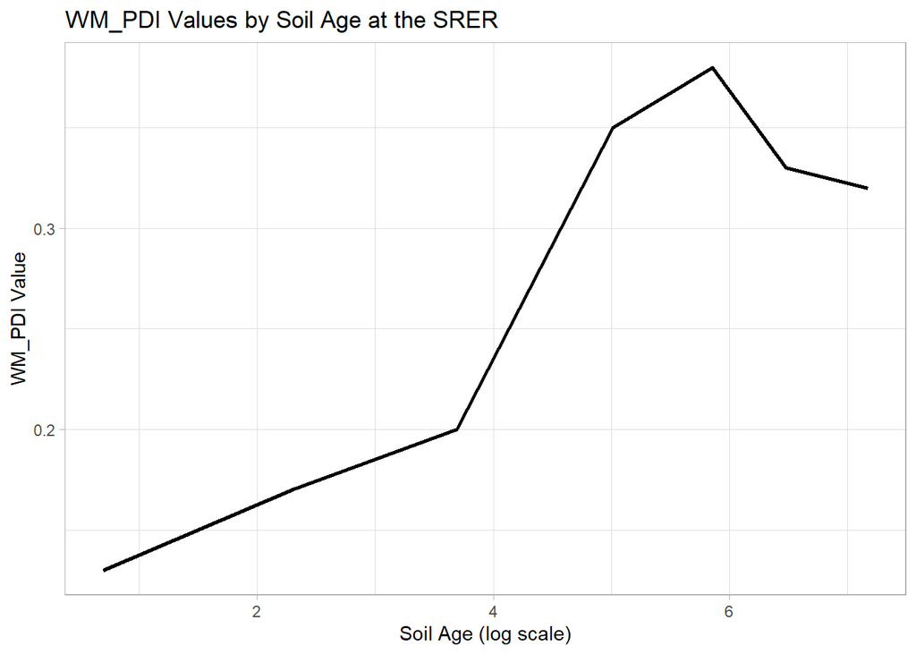

```r
ggplot(SRER1, aes(x = age_log))+
  geom_line(aes(y = WM_PDI), linewidth = 1) +
  theme_light() +
  labs(title = "WM_PDI Values by Soil Age at the SRER", x = "Soil Age (log scale)", y = "WM_PDI Value")
```

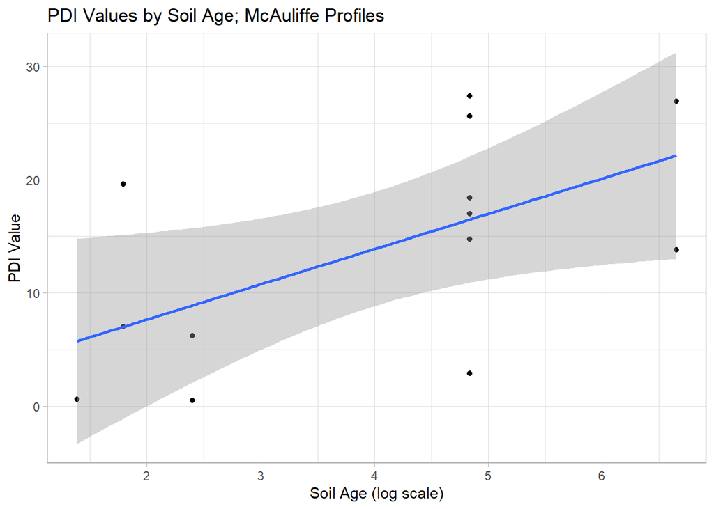

```r
McAuliffe <- read.csv("../data/McAuliffe.csv")

McAuliffe1 <- mutate(McAuliffe, age_log = log(Age))

ggplot(McAuliffe1, aes(x = age_log, y = PDI))+
  geom_point() +
  geom_smooth(method = "lm") +
  theme_light() +
  labs(title = "PDI Values by Soil Age; McAuliffe Profiles", x = "Soil Age (log scale)", y = "PDI Value")
```

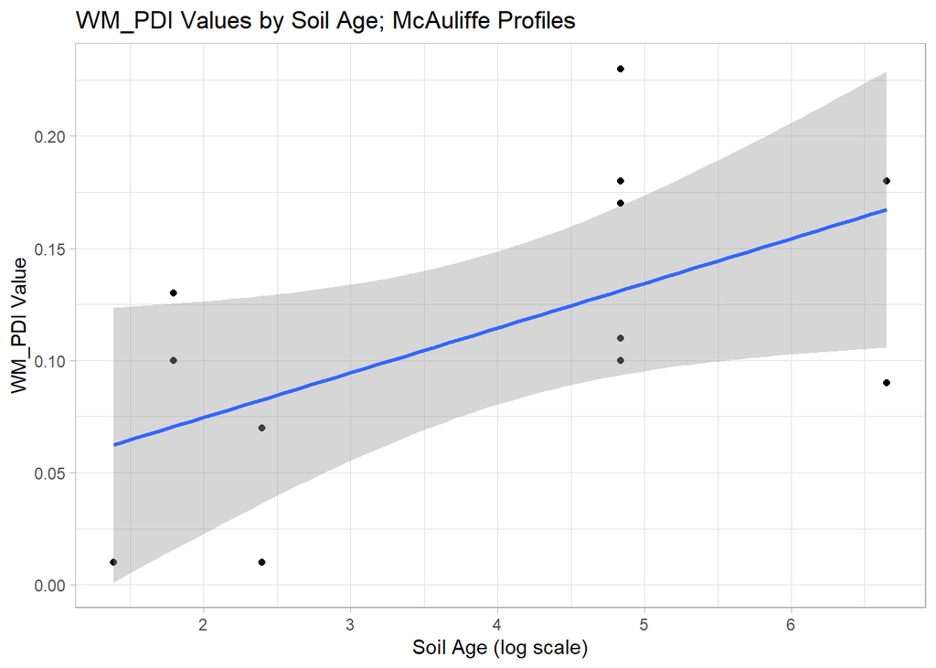

```r
ggplot(McAuliffe1, aes(x = age_log, y = WM_PDI))+
  geom_point() +
  geom_smooth(method = "lm") +
  theme_light() +
  labs(title = "WM_PDI Values by Soil Age; McAuliffe Profiles", x = "Soil Age (log scale)", y = "WM_PDI Value")
```

The McAuliffe graphs show minimal or no relationship between soil age and PDI value. Several soils of the same age had highly different PDI values.

Looking at the PDI index, signs of development include horizon formation, color, texture, structure, consistence, presence of clay films, and carbonate development. A soil that is very old has likely been leached of most minerals, horizons are unclear, and erosion might be occurring. However, erosion can occur for a variety of reasons, not just soil age, as is likely evidenced in the McAuliffe profiles.

2. Considering changes in PDI/WM PDI observed with erosion in the McAuliffe papers, do you think erosion plays any role in the observed patterns with age? Propose explanations for why SRER does or does not vary from the data from McAuliffe.

Yes, the PDI value for the Mid-Late Pleistocene site is 19.05, whereas the eroded profile of the same age is 14.74. This is more apparent with the Mid-Late Pleistocene lower site, with a PDI of 18.44; the eroded profile is 2.85. Erosion seems to “turn back time” and revert a soil back to an undeveloped state. I would guess that the SRER profiles were not in areas that high erosion potential, and thus we could see a clear relationship of soil age and PDI value.

*Component 3 - SRER Vegetation Transects*

These data were compiled for a series of long-term vegetation transects monitored across the SRER. The transects are measured every 3 years and span the entire elevation and soil age range across SRER. The data in the spreadsheet represent the averages of all these data providing an estimate of the annual aboveground native and invasive grass biomass (g/m2), the total biomass (sum of native and invasive), the fraction of the total biomass that is invasive, the average mean annual precipitation (MAP, cm/yr), the surficial geologic mapunit (Qy, Qi3, etc.), as well as ancillary data on pasture, burn history, grazing history, UTM coordinates, and elevation (m). I subset the data to only those sites that have not burned in recent history and are actively grazed by cattle. **Please note - I also included columns for MAP, Total, Native and Invasive Biomass as Box-Cox transformed data (Name of property followed by -X). This transformation helps approximate a normal distribution for statistical analysis.

**1)Data coupling:** Update the vegetation dataset with the PDI and WM PDI values from the spreadsheet with SRER and McAuliffe data. Assume all the Qy mapunits are equivalent to “Qy1” from the chronosequence data.

```r
Total_SRER <- read.csv("../data/SRER_compiled.csv")

Total_SRER1 <- Total_SRER %>%
  mutate(MapUnit_12 = replace(MapUnit_12, MapUnit_12 == "Qy", "Qy1"))

Total_SRER2 <- full_join(Total_SRER1, SRER1, join_by(MapUnit_12 == Site))
```

2. **Data analyses:**
1. Create box plots of total, native, invasive biomass, and fraction invasive by Map Unit;

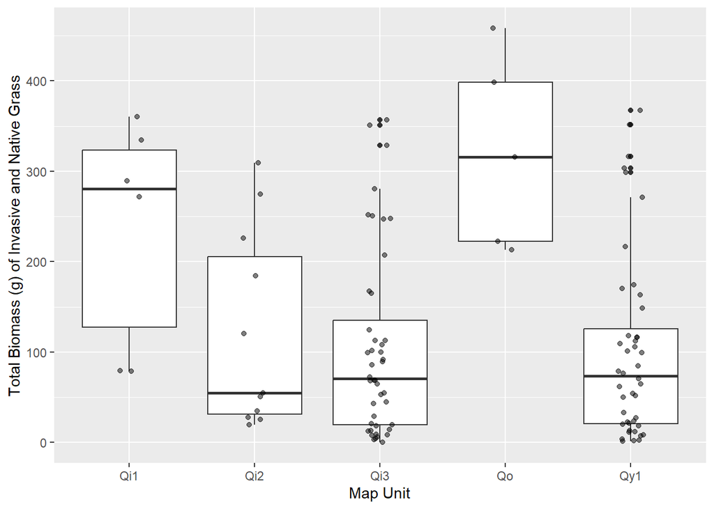

```r
rename_SRER <- Total_SRER2 %>%
  rename(pasture = PASTURE, burn_status = BURN.STATUS, grazing_status = Grazing.Status, map_unit = MapUnit_12,
         utm_x = UTM_X, utn_y = UTM_Y, elevation_m = Elevation..m., map_mm_yr = Predicted.MAP..mm.yr.,
         avg_npg_biomass = Average.NPG.Biomass..g.m..., sd_npg_biomass = Std.Dev.NPG.Biomass,
         avg_ipg_biomass = Average.IPG.Biomass..g.m..., sd_ipg_biomass = Std.Dev.IPG.Biomass,
         totalgrass_biomass = Total.Grass.Biomass..g.m..., fraction_invasive_biomass = Fraction.Invasive.Biomass,
         boxcox_Map_mm_yr = Predicted.MAP..mm.yr..X, boxcox_avg_npg_biomass = Average.NPG.Biomass..g.m....X,
         boxcox_avg_ipg_biomass = Average.IPG.Biomass..g.m....X, boxcox_totalgrass_biomass = Total.Grass.Biomass..g.m....X) %>%
  filter(!map_unit %in% c("Qi4", "Qy2"))

ggplot(rename_SRER, aes(x = map_unit, y = totalgrass_biomass)) +
  geom_boxplot() +
  geom_jitter(alpha = 0.5, width = 0.1) +
  labs(x = "Map Unit", y = "Total Biomass (g) of Invasive and Native Grass")
```

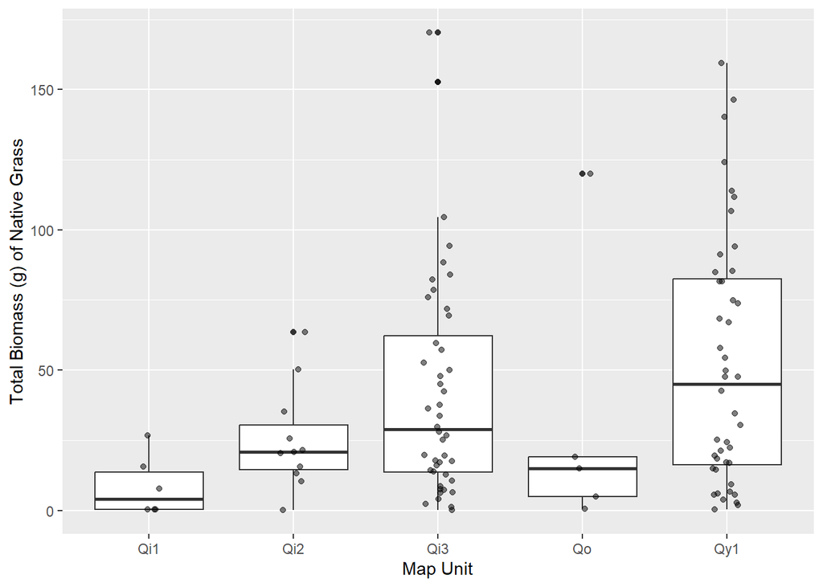

```r
ggplot(rename_SRER, aes(x = map_unit, y = avg_npg_biomass)) +
  geom_boxplot() +
  geom_jitter(alpha = 0.5, width = 0.1) +
  labs(x = "Map Unit", y = "Total Biomass (g) of Native Grass")
```

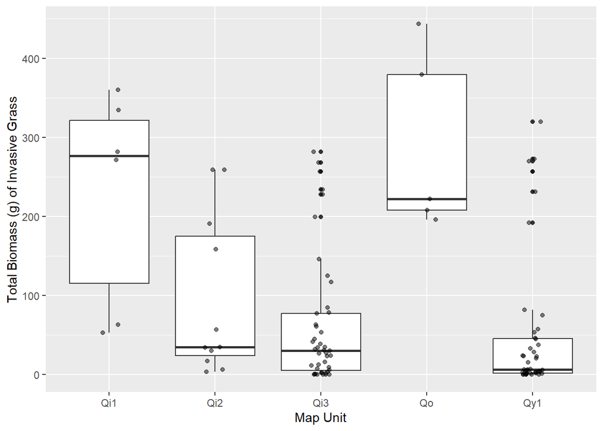

```r
ggplot(rename_SRER, aes(x = map_unit, y = avg_ipg_biomass)) +
  geom_boxplot() +
  geom_jitter(alpha = 0.5, width = 0.1) +
  labs(x = "Map Unit", y = "Total Biomass (g) of Invasive Grass")
```

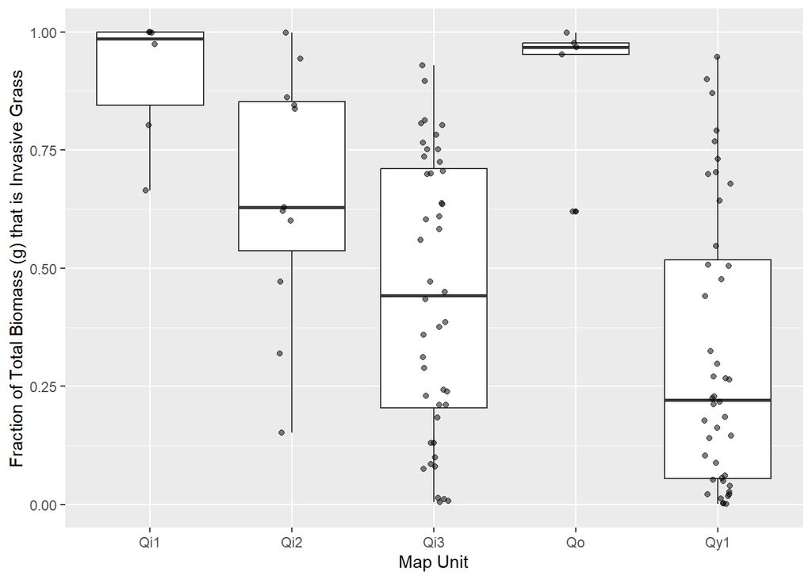

```r
ggplot(rename_SRER, aes(x = map_unit, y = fraction_invasive_biomass)) +
  geom_boxplot() +
  geom_jitter(alpha = 0.5, width = 0.1) +
  labs(x = "Map Unit", y = "Fraction of Total Biomass (g) that is Invasive Grass")
```

2. Plot total, native and invasive biomass, and fraction invasive by mean annual precipitation;

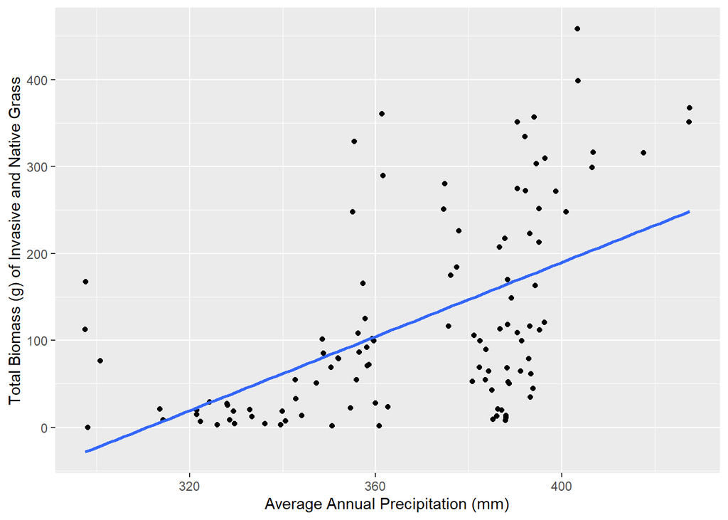

```r
ggplot(rename_SRER, aes(x = map_mm_yr, y = totalgrass_biomass)) +
  geom_point() +
  geom_smooth(method = "lm", se = F) +
  labs(x = "Average Annual Precipitation (mm)", y = "Total Biomass (g) of Invasive and Native Grass")
```

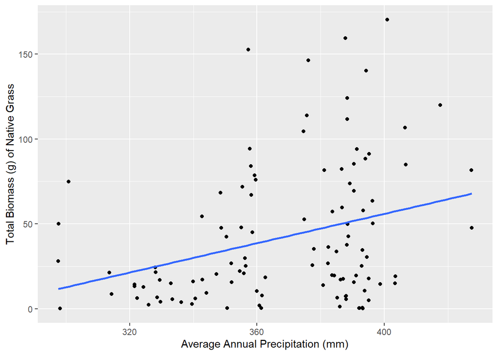

```r
ggplot(rename_SRER, aes(x = map_mm_yr, y = avg_npg_biomass)) +
  geom_point() +
  geom_smooth(method = "lm", se = F) +
  labs(x = "Average Annual Precipitation (mm)", y = "Total Biomass (g) of Native Grass")
```

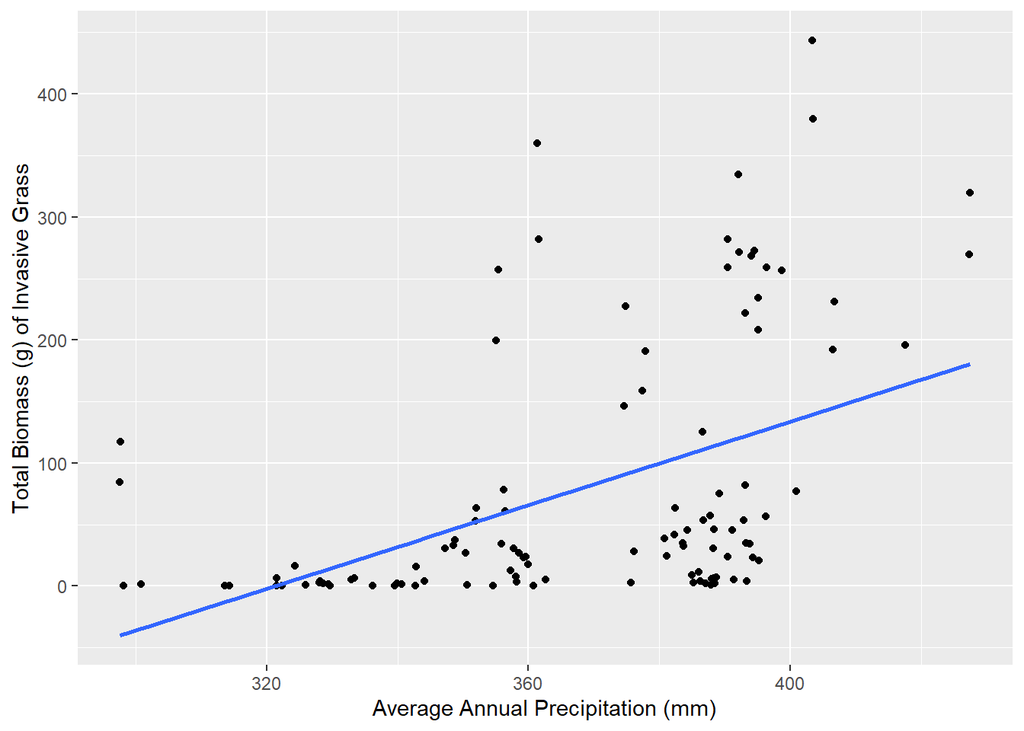

```r
ggplot(rename_SRER, aes(x = map_mm_yr, y = avg_ipg_biomass)) +
  geom_point() +
  geom_smooth(method = "lm", se = F) +
  labs(x = "Average Annual Precipitation (mm)", y = "Total Biomass (g) of Invasive Grass")
```

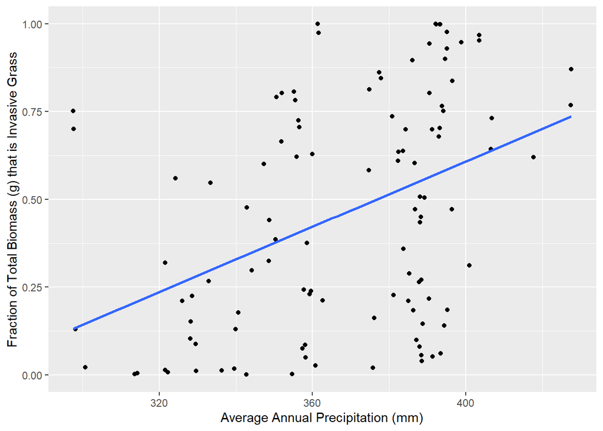

```r
ggplot(rename_SRER, aes(x = map_mm_yr, y = fraction_invasive_biomass)) +
  geom_point() +
  geom_smooth(method = "lm", se = F) +
  labs(x = "Average Annual Precipitation (mm)", y = "Fraction of Total Biomass (g) that is Invasive Grass")
```

3. Plot total, native and invasive biomass, and fraction invasive by PDI and WM PDI.

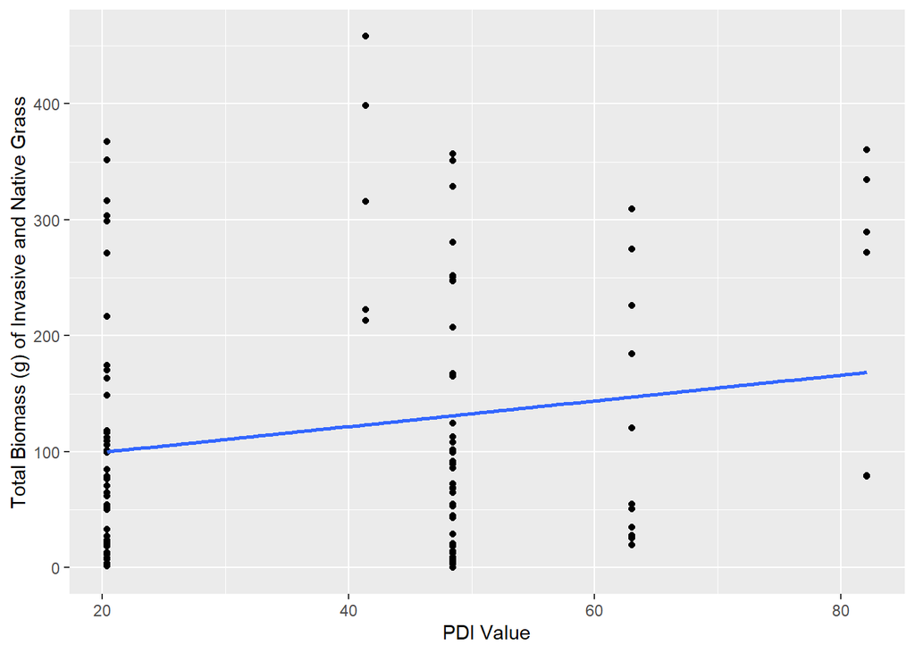

```r
ggplot(rename_SRER, aes(x = PDI, y = totalgrass_biomass)) +
  geom_point() +
  geom_smooth(method = "lm", se = F) +
  labs(x = "PDI Value", y = "Total Biomass (g) of Invasive and Native Grass")
```

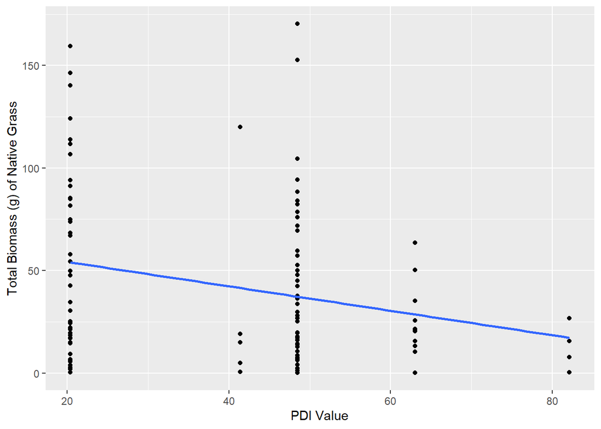

```r
ggplot(rename_SRER, aes(x = PDI, y = avg_npg_biomass)) +
  geom_point() +
  geom_smooth(method = "lm", se = F) +
  labs(x = "PDI Value", y = "Total Biomass (g) of Native Grass")
```

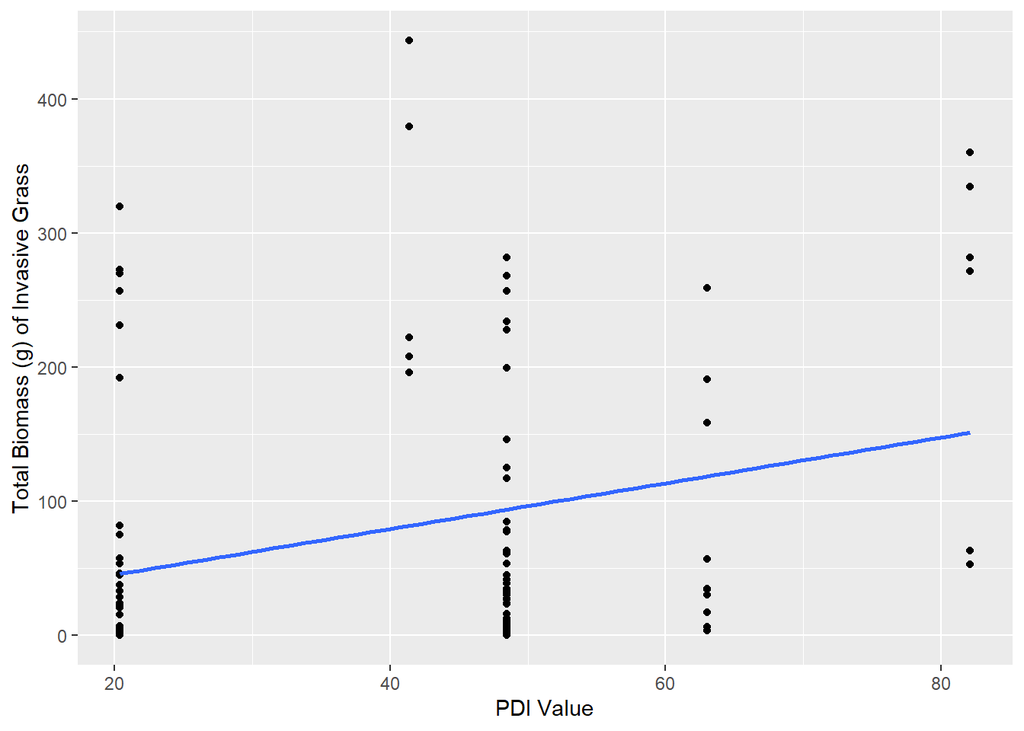

```r
ggplot(rename_SRER, aes(x = PDI, y = avg_ipg_biomass)) +
  geom_point() +
  geom_smooth(method = "lm", se = F) +
  labs(x = "PDI Value", y = "Total Biomass (g) of Invasive Grass")
```

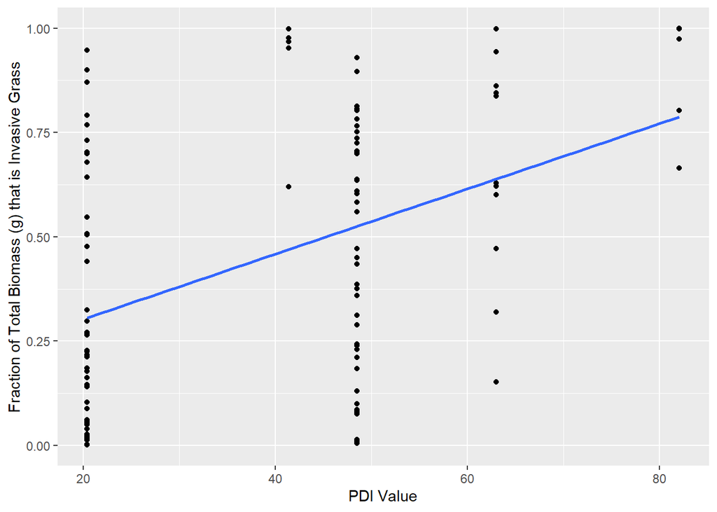

```r
ggplot(rename_SRER, aes(x = PDI, y = fraction_invasive_biomass)) +
  geom_point() +
  geom_smooth(method = "lm", se = F) +
  labs(x = "PDI Value", y = "Fraction of Total Biomass (g) that is Invasive Grass")
```

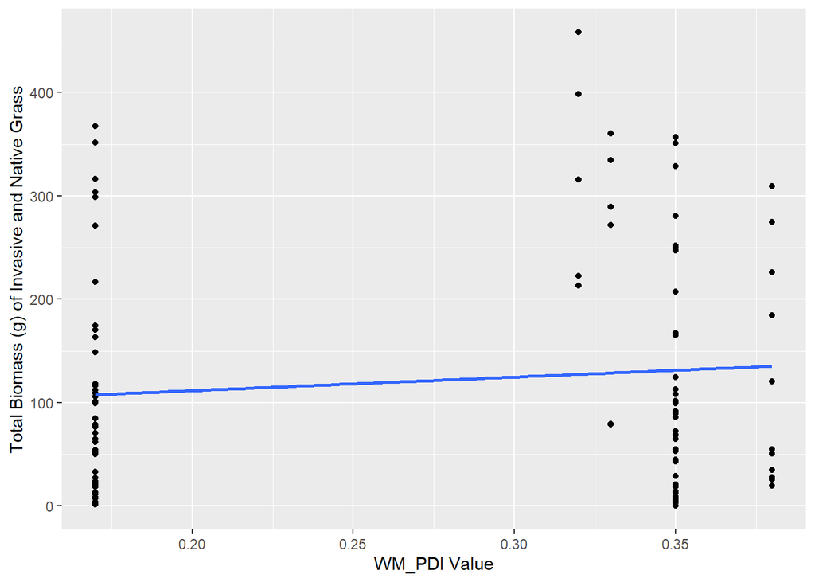

```r
ggplot(rename_SRER, aes(x = WM_PDI, y = totalgrass_biomass)) +
  geom_point() +
  geom_smooth(method = "lm", se = F) +
  labs(x = "WM_PDI Value", y = "Total Biomass (g) of Invasive and Native Grass")
```

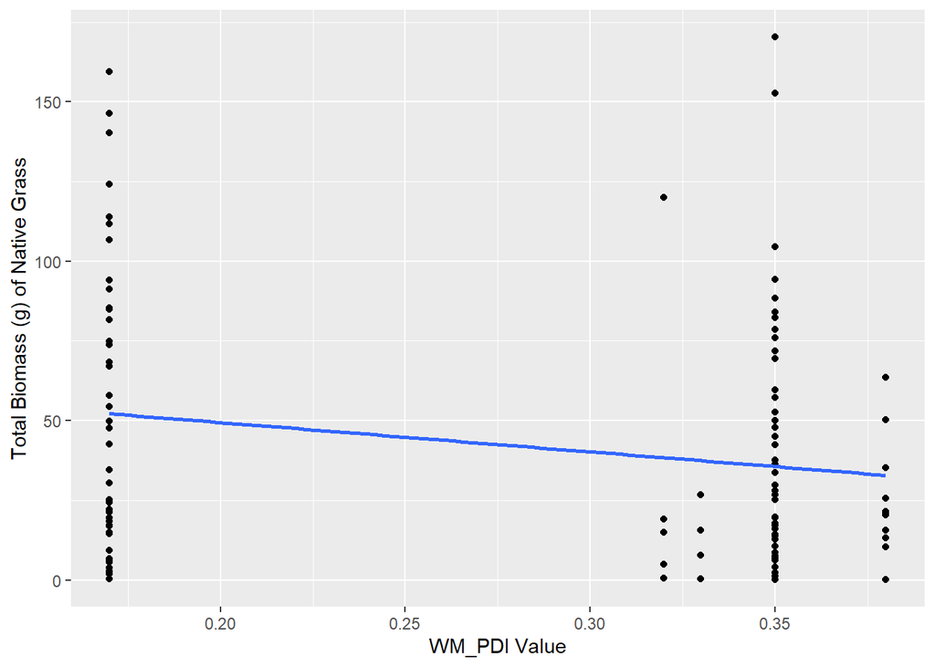

```r
ggplot(rename_SRER, aes(x = WM_PDI, y = avg_npg_biomass)) +
  geom_point() +
  geom_smooth(method = "lm", se = F) +
  labs(x = "WM_PDI Value", y = "Total Biomass (g) of Native Grass")
```

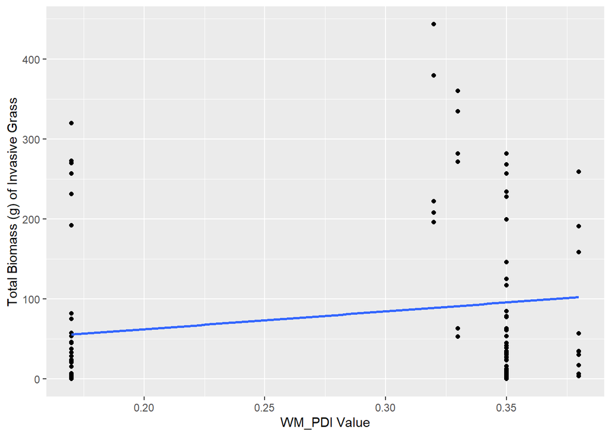

```r
ggplot(rename_SRER, aes(x = WM_PDI, y = avg_ipg_biomass)) +
  geom_point() +
  geom_smooth(method = "lm", se = F) +
  labs(x = "WM_PDI Value", y = "Total Biomass (g) of Invasive Grass")
```

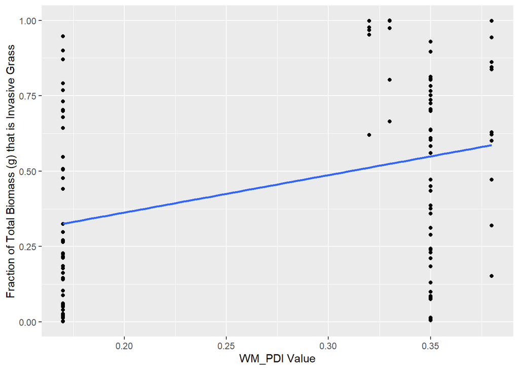

```r
ggplot(rename_SRER, aes(x = WM_PDI, y = fraction_invasive_biomass)) +
  geom_point() +
  geom_smooth(method = "lm", se = F) +
  labs(x = "WM_PDI Value", y = "Fraction of Total Biomass (g) that is Invasive Grass")
```

3. **Statistical analyses:**
1. Fit least square means linear regressions using MAP as the independent variable, and total, native and invasive biomass, and fraction invasive as dependent variables - ***use the Box-Cox transformed variables!

```r
library(emmeans)
totalgrass_model <- lm(boxcox_totalgrass_biomass ~ boxcox_Map_mm_yr, data = rename_SRER)

npg_model <- lm(boxcox_avg_npg_biomass ~ boxcox_Map_mm_yr, data = rename_SRER)

ipg_model <- lm(boxcox_avg_ipg_biomass ~ boxcox_Map_mm_yr, data = rename_SRER)

fx_model <- lm(fraction_invasive_biomass ~ boxcox_Map_mm_yr, data = rename_SRER)

summary(totalgrass_model)
```

```
##
## Call:
## lm(formula = boxcox_totalgrass_biomass ~ boxcox_Map_mm_yr, data = rename_SRER)
##
## Residuals:
##      Min       1Q   Median       3Q      Max
## -142.630  -45.685    4.069   44.880  159.939
##
## Coefficients:
##                   Estimate Std. Error t value Pr(>|t|)
## (Intercept)      -140.6469    41.3120  -3.405 0.000931 ***
## boxcox_Map_mm_yr    1.6282     0.2197   7.412 2.94e-11 ***
## ---
## Signif. codes:  0 '***' 0.001 '**' 0.01 '*' 0.05 '.' 0.1 ' ' 1
##
## Residual standard error: 66.03 on 108 degrees of freedom
## Multiple R-squared:  0.3372, Adjusted R-squared:  0.331
## F-statistic: 54.94 on 1 and 108 DF,  p-value: 2.941e-11
```

```r
summary(npg_model)
```

```
##
## Call:
## lm(formula = boxcox_avg_npg_biomass ~ boxcox_Map_mm_yr, data = rename_SRER)
##
## Residuals:
##     Min      1Q  Median      3Q     Max
## -66.702 -17.506  -1.126  19.539  54.609
##
## Coefficients:
##                  Estimate Std. Error t value Pr(>|t|)
## (Intercept)      -5.33904   16.56403  -0.322  0.74783
## boxcox_Map_mm_yr  0.27595    0.08808   3.133  0.00223 **
## ---
## Signif. codes:  0 '***' 0.001 '**' 0.01 '*' 0.05 '.' 0.1 ' ' 1
##
## Residual standard error: 26.48 on 108 degrees of freedom
## Multiple R-squared:  0.08332,    Adjusted R-squared:  0.07483
## F-statistic: 9.816 on 1 and 108 DF,  p-value: 0.002227
```

```r
summary(ipg_model)
```

```
##
## Call:
## lm(formula = boxcox_avg_ipg_biomass ~ boxcox_Map_mm_yr, data = rename_SRER)
##
## Residuals:
##     Min      1Q  Median      3Q     Max
## -60.434 -21.430  -0.983  22.050  76.952
##
## Coefficients:
##                   Estimate Std. Error t value Pr(>|t|)
## (Intercept)      -92.17032   18.59283  -4.957 2.67e-06 ***
## boxcox_Map_mm_yr   0.72438    0.09886   7.327 4.49e-11 ***
## ---
## Signif. codes:  0 '***' 0.001 '**' 0.01 '*' 0.05 '.' 0.1 ' ' 1
##
## Residual standard error: 29.72 on 108 degrees of freedom
## Multiple R-squared:  0.332,  Adjusted R-squared:  0.3259
## F-statistic: 53.69 on 1 and 108 DF,  p-value: 4.493e-11
```

```r
summary(fx_model)
```

```
##
## Call:
## lm(formula = fraction_invasive_biomass ~ boxcox_Map_mm_yr, data = rename_SRER)
##
## Residuals:
##      Min       1Q   Median       3Q      Max
## -0.51811 -0.24763 -0.02941  0.24916  0.60316
##
## Coefficients:
##                   Estimate Std. Error t value Pr(>|t|)
## (Intercept)      -0.429467   0.187315  -2.293   0.0238 *
## boxcox_Map_mm_yr  0.004788   0.000996   4.807 4.98e-06 ***
## ---
## Signif. codes:  0 '***' 0.001 '**' 0.01 '*' 0.05 '.' 0.1 ' ' 1
##
## Residual standard error: 0.2994 on 108 degrees of freedom
## Multiple R-squared:  0.1762, Adjusted R-squared:  0.1686
## F-statistic: 23.11 on 1 and 108 DF,  p-value: 4.981e-06
```

2. Fit least square means linear regressions using estimated age, PDI, and WM-PDI as the independent variable, and total, native and invasive biomass, and fraction invasive as dependent variables - ***use the Box-Cox transformed biomass data!

```r
totalgrass_age_model <- lm(boxcox_totalgrass_biomass ~ age_log, data = rename_SRER)

npg_age_model <- lm(boxcox_avg_npg_biomass ~ age_log, data = rename_SRER)

ipg_age_model <- lm(boxcox_avg_ipg_biomass ~ age_log, data = rename_SRER)

fx_age_model <- lm(fraction_invasive_biomass ~ age_log, data = rename_SRER)

summary(totalgrass_age_model)
```

```
##
## Call:
## lm(formula = boxcox_totalgrass_biomass ~ age_log, data = rename_SRER)
##
## Residuals:
##      Min       1Q   Median       3Q      Max
## -206.743  -56.126    4.682   65.498  149.450
##
## Coefficients:
##             Estimate Std. Error t value Pr(>|t|)
## (Intercept)  112.799     20.701   5.449 3.22e-07 ***
## age_log       11.737      4.604   2.550   0.0122 *
## ---
## Signif. codes:  0 '***' 0.001 '**' 0.01 '*' 0.05 '.' 0.1 ' ' 1
##
## Residual standard error: 78.77 on 108 degrees of freedom
## Multiple R-squared:  0.05677,    Adjusted R-squared:  0.04804
## F-statistic:   6.5 on 1 and 108 DF,  p-value: 0.01219
```

```r
summary(npg_age_model)
```

```
##
## Call:
## lm(formula = boxcox_avg_npg_biomass ~ age_log, data = rename_SRER)
##
## Residuals:
##     Min      1Q  Median      3Q     Max
## -61.283 -17.521   0.978  20.278  59.398
##
## Coefficients:
##             Estimate Std. Error t value Pr(>|t|)
## (Intercept)   64.541      7.009   9.208 2.94e-15 ***
## age_log       -4.436      1.559  -2.846   0.0053 **
## ---
## Signif. codes:  0 '***' 0.001 '**' 0.01 '*' 0.05 '.' 0.1 ' ' 1
##
## Residual standard error: 26.67 on 108 degrees of freedom
## Multiple R-squared:  0.06976,    Adjusted R-squared:  0.06115
## F-statistic:   8.1 on 1 and 108 DF,  p-value: 0.005299
```

```r
summary(ipg_age_model)
```

```
##
## Call:
## lm(formula = boxcox_avg_ipg_biomass ~ age_log, data = rename_SRER)
##
## Residuals:
##     Min      1Q  Median      3Q     Max
## -79.241 -20.602  -3.604  25.386  71.736
##
## Coefficients:
##             Estimate Std. Error t value Pr(>|t|)
## (Intercept)    6.448      8.802   0.733    0.465
## age_log        8.597      1.958   4.391 2.64e-05 ***
## ---
## Signif. codes:  0 '***' 0.001 '**' 0.01 '*' 0.05 '.' 0.1 ' ' 1
##
## Residual standard error: 33.49 on 108 degrees of freedom
## Multiple R-squared:  0.1515, Adjusted R-squared:  0.1437
## F-statistic: 19.28 on 1 and 108 DF,  p-value: 2.637e-05
```

```r
summary(fx_age_model)
```

```
##
## Call:
## lm(formula = fraction_invasive_biomass ~ age_log, data = rename_SRER)
##
## Residuals:
##      Min       1Q   Median       3Q      Max
## -0.53260 -0.23856 -0.01333  0.22639  0.66542
##
## Coefficients:
##             Estimate Std. Error t value Pr(>|t|)
## (Intercept)  0.06207    0.07631   0.813    0.418
## age_log      0.09507    0.01697   5.602 1.63e-07 ***
## ---
## Signif. codes:  0 '***' 0.001 '**' 0.01 '*' 0.05 '.' 0.1 ' ' 1
##
## Residual standard error: 0.2904 on 108 degrees of freedom
## Multiple R-squared:  0.2251, Adjusted R-squared:  0.218
## F-statistic: 31.38 on 1 and 108 DF,  p-value: 1.634e-07
```

```r
totalgrass_PDI_model <- lm(boxcox_totalgrass_biomass ~ PDI, data = rename_SRER)

npg_PDI_model <- lm(boxcox_avg_npg_biomass ~ PDI, data = rename_SRER)

ipg_PDI_model <- lm(boxcox_avg_ipg_biomass ~ PDI, data = rename_SRER)

fx_PDI_model <- lm(fraction_invasive_biomass ~ PDI, data = rename_SRER)

summary(totalgrass_PDI_model)
```

```
##
## Call:
## lm(formula = boxcox_totalgrass_biomass ~ PDI, data = rename_SRER)
##
## Residuals:
##      Min       1Q   Median       3Q      Max
## -203.429  -63.166    4.199   66.736  150.331
##
## Coefficients:
##             Estimate Std. Error t value Pr(>|t|)
## (Intercept) 131.3064    18.4533   7.116 1.28e-10 ***
## PDI           0.7627     0.4179   1.825   0.0708 .
## ---
## Signif. codes:  0 '***' 0.001 '**' 0.01 '*' 0.05 '.' 0.1 ' ' 1
##
## Residual standard error: 79.88 on 108 degrees of freedom
## Multiple R-squared:  0.02992,    Adjusted R-squared:  0.02094
## F-statistic: 3.331 on 1 and 108 DF,  p-value: 0.07076
```

```r
summary(npg_PDI_model)
```

```
##
## Call:
## lm(formula = boxcox_avg_npg_biomass ~ PDI, data = rename_SRER)
##
## Residuals:
##     Min      1Q  Median      3Q     Max
## -61.490 -18.867   2.206  20.071  59.343
##
## Coefficients:
##             Estimate Std. Error t value Pr(>|t|)
## (Intercept)  63.3653     6.1172  10.359  < 2e-16 ***
## PDI          -0.4330     0.1385  -3.125  0.00228 **
## ---
## Signif. codes:  0 '***' 0.001 '**' 0.01 '*' 0.05 '.' 0.1 ' ' 1
##
## Residual standard error: 26.48 on 108 degrees of freedom
## Multiple R-squared:  0.08294,    Adjusted R-squared:  0.07445
## F-statistic: 9.767 on 1 and 108 DF,  p-value: 0.002282
```

```r
summary(ipg_PDI_model)
```

```
##
## Call:
## lm(formula = boxcox_avg_ipg_biomass ~ PDI, data = rename_SRER)
##
## Residuals:
##     Min      1Q  Median      3Q     Max
## -77.606 -22.293  -2.612  25.491  68.476
##
## Coefficients:
##             Estimate Std. Error t value Pr(>|t|)
## (Intercept)  16.1562     7.9264   2.038 0.043965 *
## PDI           0.6542     0.1795   3.645 0.000413 ***
## ---
## Signif. codes:  0 '***' 0.001 '**' 0.01 '*' 0.05 '.' 0.1 ' ' 1
##
## Residual standard error: 34.31 on 108 degrees of freedom
## Multiple R-squared:  0.1095, Adjusted R-squared:  0.1013
## F-statistic: 13.28 on 1 and 108 DF,  p-value: 0.0004133
```

```r
summary(fx_PDI_model)
```

```
##
## Call:
## lm(formula = fraction_invasive_biomass ~ PDI, data = rename_SRER)
##
## Residuals:
##      Min       1Q   Median       3Q      Max
## -0.51927 -0.25485 -0.03661  0.21172  0.64073
##
## Coefficients:
##             Estimate Std. Error t value Pr(>|t|)
## (Intercept) 0.146367   0.068599   2.134   0.0351 *
## PDI         0.007809   0.001554   5.026    2e-06 ***
## ---
## Signif. codes:  0 '***' 0.001 '**' 0.01 '*' 0.05 '.' 0.1 ' ' 1
##
## Residual standard error: 0.297 on 108 degrees of freedom
## Multiple R-squared:  0.1896, Adjusted R-squared:  0.1821
## F-statistic: 25.27 on 1 and 108 DF,  p-value: 1.995e-06
```

```r
totalgrass_WMPDI_model <- lm(boxcox_totalgrass_biomass ~ WM_PDI, data = rename_SRER)

npg_WMPDI_model <- lm(boxcox_avg_npg_biomass ~ WM_PDI, data = rename_SRER)

ipg_WMPDI_model <- lm(boxcox_avg_ipg_biomass ~ WM_PDI, data = rename_SRER)

fx_WMPDI_model <- lm(fraction_invasive_biomass ~ WM_PDI, data = rename_SRER)

summary(totalgrass_WMPDI_model)
```

```
##
## Call:
## lm(formula = boxcox_totalgrass_biomass ~ WM_PDI, data = rename_SRER)
##
## Residuals:
##      Min       1Q   Median       3Q      Max
## -203.519  -64.545    1.461   66.895  147.515
##
## Coefficients:
##             Estimate Std. Error t value Pr(>|t|)
## (Intercept)   137.01      25.16   5.446 3.26e-07 ***
## WM_PDI         89.65      85.99   1.043      0.3
## ---
## Signif. codes:  0 '***' 0.001 '**' 0.01 '*' 0.05 '.' 0.1 ' ' 1
##
## Residual standard error: 80.7 on 108 degrees of freedom
## Multiple R-squared:  0.009963,   Adjusted R-squared:  0.000796
## F-statistic: 1.087 on 1 and 108 DF,  p-value: 0.2995
```

```r
summary(npg_WMPDI_model)
```

```
##
## Call:
## lm(formula = boxcox_avg_npg_biomass ~ WM_PDI, data = rename_SRER)
##
## Residuals:
##     Min      1Q  Median      3Q     Max
## -59.091 -17.263  -0.829  21.357  59.828
##
## Coefficients:
##             Estimate Std. Error t value Pr(>|t|)
## (Intercept)    61.82       8.47   7.298 5.18e-11 ***
## WM_PDI        -56.96      28.95  -1.967   0.0517 .
## ---
## Signif. codes:  0 '***' 0.001 '**' 0.01 '*' 0.05 '.' 0.1 ' ' 1
##
## Residual standard error: 27.17 on 108 degrees of freedom
## Multiple R-squared:  0.0346, Adjusted R-squared:  0.02566
## F-statistic: 3.871 on 1 and 108 DF,  p-value: 0.0517
```

```r
summary(ipg_WMPDI_model)
```

```
##
## Call:
## lm(formula = boxcox_avg_ipg_biomass ~ WM_PDI, data = rename_SRER)
##
## Residuals:
##     Min      1Q  Median      3Q     Max
## -79.469 -23.759  -2.753  26.372  66.568
##
## Coefficients:
##             Estimate Std. Error t value Pr(>|t|)
## (Intercept)    14.09      10.97   1.285  0.20159
## WM_PDI        101.88      37.48   2.718  0.00765 **
## ---
## Signif. codes:  0 '***' 0.001 '**' 0.01 '*' 0.05 '.' 0.1 ' ' 1
##
## Residual standard error: 35.18 on 108 degrees of freedom
## Multiple R-squared:  0.06402,    Adjusted R-squared:  0.05536
## F-statistic: 7.388 on 1 and 108 DF,  p-value: 0.007652
```

```r
summary(fx_WMPDI_model)
```

```
##
## Call:
## lm(formula = fraction_invasive_biomass ~ WM_PDI, data = rename_SRER)
##
## Residuals:
##     Min      1Q  Median      3Q     Max
## -0.5433 -0.2727 -0.0138  0.2526  0.6208
##
## Coefficients:
##             Estimate Std. Error t value Pr(>|t|)
## (Intercept)  0.11452    0.09671   1.184 0.238966
## WM_PDI       1.24188    0.33056   3.757 0.000279 ***
## ---
## Signif. codes:  0 '***' 0.001 '**' 0.01 '*' 0.05 '.' 0.1 ' ' 1
##
## Residual standard error: 0.3102 on 108 degrees of freedom
## Multiple R-squared:  0.1156, Adjusted R-squared:  0.1074
## F-statistic: 14.11 on 1 and 108 DF,  p-value: 0.0002793
```

3. Multiple linear regression - include MAP and the age variable with the best correlation (estimated age, PDI or WM-PDI) and their interaction term (MAP x Age) as the independent variables and total, native and invasive biomass, and fraction invasive as dependent variables - ***use the Box-Cox transformed variables!

[output not shown]

The variable log_age has the most consistently high adjusted R^2 values, so that is what I will use for the multiple linear regression models.

```r
mlr_total <- lm(boxcox_totalgrass_biomass ~ map_mm_yr * age_log,
                data = rename_SRER)

mlr_npg <- lm(boxcox_avg_npg_biomass ~ map_mm_yr * age_log, data = rename_SRER)

mlr_ipg <- lm(boxcox_avg_ipg_biomass ~ map_mm_yr * age_log, data = rename_SRER)

mlr_fx <- lm(fraction_invasive_biomass ~ map_mm_yr * age_log, data = rename_SRER)

summary(mlr_total)
```

```
##
## Call:
## lm(formula = boxcox_totalgrass_biomass ~ map_mm_yr * age_log,
##     data = rename_SRER)
##
## Residuals:
##      Min       1Q   Median       3Q      Max
## -149.743  -40.432    6.227   42.084  148.870
##
## Coefficients:
##                     Estimate Std. Error t value Pr(>|t|)
## (Intercept)       -584.61973  213.98356  -2.732  0.00737 **
## map_mm_yr            1.90330    0.57322   3.320  0.00123 **
## age_log             42.29592   49.01182   0.863  0.39010
## map_mm_yr:age_log   -0.08509    0.13079  -0.651  0.51672
## ---
## Signif. codes:  0 '***' 0.001 '**' 0.01 '*' 0.05 '.' 0.1 ' ' 1
##
## Residual standard error: 64.59 on 106 degrees of freedom
## Multiple R-squared:  0.3776, Adjusted R-squared:  0.3599
## F-statistic: 21.43 on 3 and 106 DF,  p-value: 6.311e-11
```

```r
summary(mlr_npg)
```

```
##
## Call:
## lm(formula = boxcox_avg_npg_biomass ~ map_mm_yr * age_log, data = rename_SRER)
##
## Residuals:
##     Min      1Q  Median      3Q     Max
## -56.076 -16.441  -1.129  17.482  56.681
##
## Coefficients:
##                     Estimate Std. Error t value Pr(>|t|)
## (Intercept)       -176.92721   83.53299  -2.118  0.03651 *
## map_mm_yr            0.65323    0.22377   2.919  0.00429 **
## age_log             29.41750   19.13280   1.538  0.12714
## map_mm_yr:age_log   -0.09121    0.05106  -1.786  0.07690 .
## ---
## Signif. codes:  0 '***' 0.001 '**' 0.01 '*' 0.05 '.' 0.1 ' ' 1
##
## Residual standard error: 25.21 on 106 degrees of freedom
## Multiple R-squared:  0.184,  Adjusted R-squared:  0.1609
## F-statistic: 7.967 on 3 and 106 DF,  p-value: 7.705e-05
```

```r
summary(mlr_ipg)
```

```
##
## Call:
## lm(formula = boxcox_avg_ipg_biomass ~ map_mm_yr * age_log, data = rename_SRER)
##
## Residuals:
##     Min      1Q  Median      3Q     Max
## -66.053 -19.372  -0.181  19.158  67.664
##
## Coefficients:
##                     Estimate Std. Error t value Pr(>|t|)
## (Intercept)       -324.34758   89.06493  -3.642 0.000421 ***
## map_mm_yr            0.90158    0.23859   3.779 0.000261 ***
## age_log             27.86085   20.39986   1.366 0.174912
## map_mm_yr:age_log   -0.05302    0.05444  -0.974 0.332343
## ---
## Signif. codes:  0 '***' 0.001 '**' 0.01 '*' 0.05 '.' 0.1 ' ' 1
##
## Residual standard error: 26.88 on 106 degrees of freedom
## Multiple R-squared:  0.4635, Adjusted R-squared:  0.4483
## F-statistic: 30.53 on 3 and 106 DF,  p-value: 2.644e-14
```

```r
summary(mlr_fx)
```

```
##
## Call:
## lm(formula = fraction_invasive_biomass ~ map_mm_yr * age_log,
##     data = rename_SRER)
##
## Residuals:
##      Min       1Q   Median       3Q      Max
## -0.54146 -0.22543  0.02688  0.20779  0.58514
##
## Coefficients:
##                     Estimate Std. Error t value Pr(>|t|)
## (Intercept)       -1.7182788  0.8676829  -1.980   0.0503 .
## map_mm_yr          0.0048689  0.0023243   2.095   0.0386 *
## age_log            0.1316788  0.1987383   0.663   0.5090
## map_mm_yr:age_log -0.0001074  0.0005304  -0.202   0.8399
## ---
## Signif. codes:  0 '***' 0.001 '**' 0.01 '*' 0.05 '.' 0.1 ' ' 1
##
## Residual standard error: 0.2619 on 106 degrees of freedom
## Multiple R-squared:  0.3813, Adjusted R-squared:  0.3638
## F-statistic: 21.78 on 3 and 106 DF,  p-value: 4.598e-11
```

**4) Summary and Conclusions**

Create figures and tables summarizing the data analysis and provide a detailed discussion of the data patterns and propose explanations for observed patterns. The discussion of the data should pull examples for comparison from the published literature.

```r
library(sjPlot)
#creates a table of model summaries
tab_model(mlr_total, mlr_npg, mlr_ipg, mlr_fx)
```

|  | boxcox totalgrass biomass |  |  | boxcox avg npg biomass |  |  | boxcox avg ipg biomass |  |  | fraction invasive biomass |  |  |
| --- | --- | --- | --- | --- | --- | --- | --- | --- | --- | --- | --- | --- |
| Predictors | Estimates | CI | p | Estimates | CI | p | Estimates | CI | p | Estimates | CI | p |
| (Intercept) | -584.62 | -1008.86 – -160.38 | **0.007** | -176.93 | -342.54 – -11.31 | **0.037** | -324.35 | -500.93 – -147.77 | **<0.001** | -1.72 | -3.44 – 0.00 | 0.050 |
| map mm yr | 1.90 | 0.77 – 3.04 | **0.001** | 0.65 | 0.21 – 1.10 | **0.004** | 0.90 | 0.43 – 1.37 | **<0.001** | 0.00 | 0.00 – 0.01 | **0.039** |
| age log | 42.30 | -54.87 – 139.47 | 0.390 | 29.42 | -8.52 – 67.35 | 0.127 | 27.86 | -12.58 – 68.31 | 0.175 | 0.13 | -0.26 – 0.53 | 0.509 |
| map mm yr × age log | -0.09 | -0.34 – 0.17 | 0.517 | -0.09 | -0.19 – 0.01 | 0.077 | -0.05 | -0.16 – 0.05 | 0.332 | -0.00 | -0.00 – 0.00 | 0.840 |
| Observations | 110 |  |  | 110 |  |  | 110 |  |  | 110 |  |  |
| R<sup>2</sup> / R<sup>2</sup> adjusted | 0.378 / 0.360 |  |  | 0.184 / 0.161 |  |  | 0.464 / 0.448 |  |  | 0.381 / 0.364 |  |  |

Results: Mean annual precipitation (MAP) is the dominant driver for biomass (p < 0.05) across all vegetation types. No significance was found in interactions between soil age and MAP (p > 0.05) in all models. The model explained 45% of variance in invasive grass biomass (adjusted R^2 = 0.448) and only 16% in native grass (adjusted R^2 = 0.161).

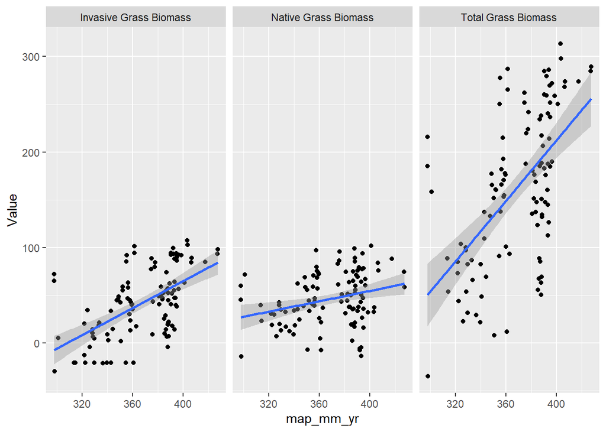

```r
long_SRER <- rename_SRER %>%
  pivot_longer(
    cols = c(boxcox_totalgrass_biomass, boxcox_avg_npg_biomass,
             boxcox_avg_ipg_biomass),
    names_to = "Biomass_Type",
    values_to = "Value"
  ) %>%
  mutate(Biomass_Type = recode(Biomass_Type,
    "boxcox_totalgrass_biomass" = "Total Grass Biomass",
    "boxcox_avg_npg_biomass"    = "Native Grass Biomass",
    "boxcox_avg_ipg_biomass"    = "Invasive Grass Biomass"
  ))

ggplot(long_SRER, aes(x = map_mm_yr, y = Value)) +
  geom_point() +
  geom_smooth(method = "lm") +
  facet_wrap(~ Biomass_Type)
```

Discussion:

Here we have 2 datasets, a set from the Santa Rita Experimental Range (SRER), and another set from the Tucson Mountains, Tortolitas, and the Silverbell mountains. Both show general trends of PDI value increasing with soil age, but with high variation in eroded sites (McAuliffe, 1994). While PDI values are generally seen as a proxy for soil age, several soil profiles here are exceptions to this rule, so PDI alone cannot be used as an accurate predictor of soil age. Another general trend of soil age is vegetation type. As soils age, certain vegetation can no longer persist there. We can see this in these soil profiles, as native and invasive grass have an inverse relationship to PDI, with invasive grass generally increasing with PDI value, and native grass decreasing. This raises an interesting question, why can invasive grass persist on older soil surfaces? Old soils are generally leached of available minerals, and yet Lehmann’s lovegrass is prevalent. Mean annual precipitation (MAP) adds another piece to the puzzle, and is our strongest predictor of grass biomass. Interestingly, native grass respond less aggressively to higher MAP, perhaps indicating that they are less dependent on moisture or more drought tolerant than invasive grasses. The lack of significant interaction between MAP and soil age suggests that these two variables act independently on biomass, and that precipitation effect is stable across all vegetation types.

McAuliffe, J. (1994). Landscape Evolution, Soil Formation, and Ecological Patterns and Processes in Sonoran Desert Bajadas. *Ecological Monographs, 64*(2): 111-148.